# Relatório de Análise de Componentes Principais (PCA) da Gestão de Resíduos Sólidos em Minas Gerais (2019-2021)

Author

### Introdução

A gestão eficiente de resíduos sólidos é crucial para o desenvolvimento sustentável, afetando a saúde pública, o meio ambiente e a qualidade de vida nas comunidades. Este relatório utiliza a Análise de Componentes Principais (PCA) para investigar os fatores que influenciam a gestão de resíduos sólidos em Minas Gerais entre 2019 e 2021. A PCA permite identificar os componentes principais que explicam a maior parte da variância dos indicadores de gestão de resíduos, facilitando a compreensão das relações entre diferentes variáveis.

### Metodologia

Os dados foram extraídos da planilha “Planilha_2021-Residuos.xlsx”, que contém informações sobre a gestão de resíduos em municípios brasileiros. A análise foi conduzida utilizando o software R. As etapas do processo incluíram:

1. **Pré-processamento:** Importação dos dados, criação de uma variável “Ano” com a identificação do ano correspondente, e conversão da variável “CS001” (Coleta Seletiva) para formato binário (0 representando “Não” e 1 representando “Sim”).
2. **Filtragem e Limpeza:** Remoção de valores ausentes (NA) e seleção dos dados exclusivamente dos municípios de Minas Gerais, assegurando a relevância geográfica da análise.
3. **Normalização:** Padronização das variáveis numéricas para média zero e desvio padrão um, garantindo que todas as variáveis contribuam igualmente para a análise, evitando viés devido a escalas diferentes.
4. **PCA:** Aplicação da PCA às variáveis normalizadas, permitindo a redução da dimensionalidade e a identificação dos componentes principais.

### Resultados e Discussão

#### Variância Explicada e Scree Plot:

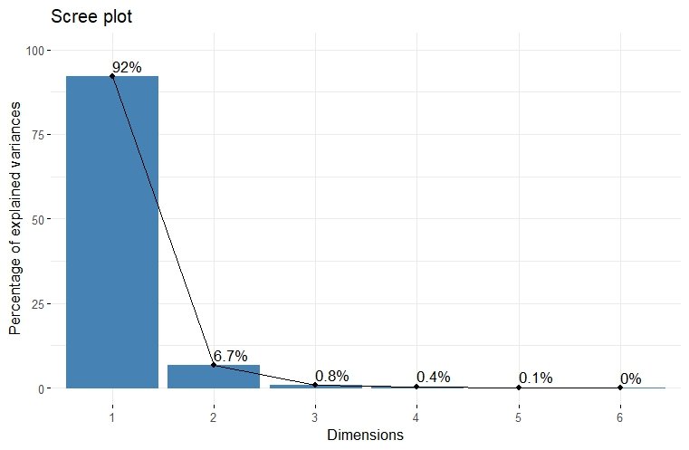

Scree Plot

O Scree Plot demonstra a variância explicada por cada componente principal. O primeiro componente (PC1) explica 92% da variância total, sugerindo que este componente captura a maior parte da informação contida nos dados originais. O segundo componente (PC2) contribui com 6,7%. Essa alta concentração da variância no PC1 indica a presença de um fator dominante que influencia significativamente a gestão de resíduos sólidos em Minas Gerais.

#### Correlação entre Variáveis e Componentes Principais:

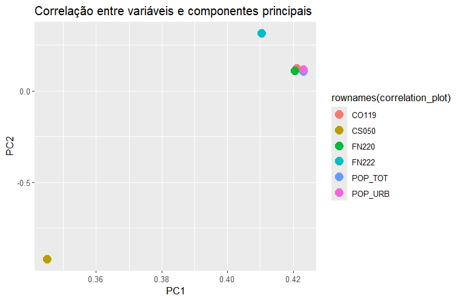

Correlação entre Variáveis e Componentes Principais

A correlação entre as variáveis originais e os dois primeiros componentes principais revela agrupamentos significativos. As variáveis relacionadas à população (POP_TOT, POP_URB) e à coleta seletiva (CO119) estão interligadas, enquanto a variável CS050 (serviço de coleta seletiva) mostra uma relação distinta, sugerindo diferentes fatores que influenciam a gestão de resíduos.

#### Contribuição das Variáveis para PC1:

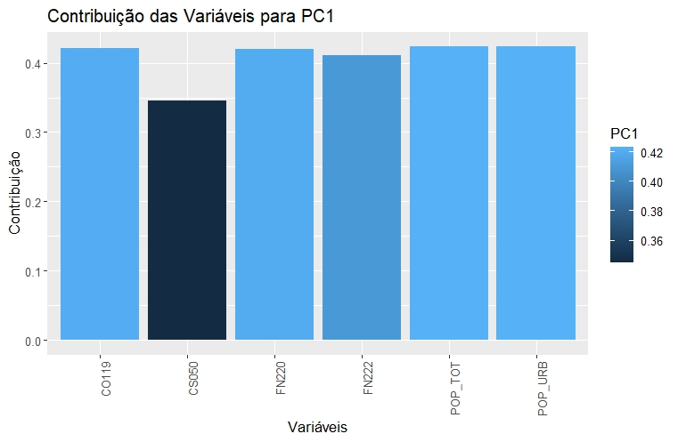

Contribuição das Variáveis para PC1

O gráfico de barras destaca a contribuição de cada variável para o PC1, com POP_TOT, POP_URB, FN220 e FN222 apresentando contribuições elevadas. A variável CS050 apresenta a menor contribuição, reforçando a importância relativa de fatores demográficos e FN220 e FN222 na formação do componente principal.

#### Distribuição dos Municípios por PC1 e PC2 e sua Temporalidade:

[figure not shown]

[figure not shown]

#### Mapas de Distribuição Espacial:

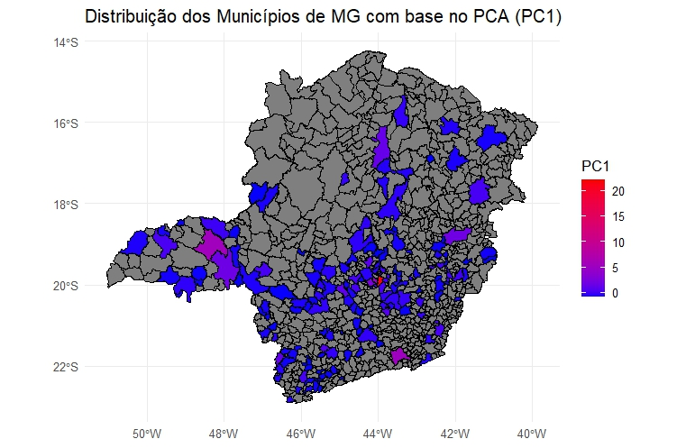

[figure not shown]

Os mapas mostram a distribuição espacial do PC1 em Minas Gerais, revelando concentrações elevadas de valores em regiões específicas, possivelmente associadas a maior população ou melhores indicadores de gestão de resíduos.

#### PCA - Análise das Variáveis e Biplot:

[figure not shown]

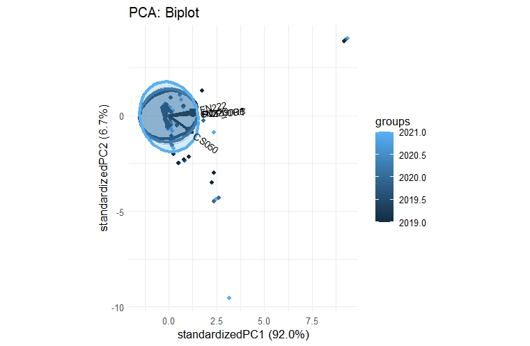

As Figuras apresentadas permitem uma visualização da relação entre as variáveis e os componentes principais, com a proximidade entre municípios e variáveis sugerindo influências importantes.

#### Matriz de Correlação:

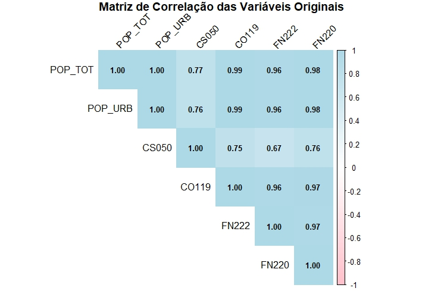

Matriz de Correlação das Variáveis Originais

A matriz de correlação revela relações lineares entre as variáveis, permitindo identificar padrões que ajudam a entender como os indicadores de gestão de resíduos se inter-relacionam. A alta correlação entre POP_TOT e POP_URB sugere dependências significativas.

### Conclusões

A PCA revelou que um único componente principal (PC1) explica a maior parte da variância nos dados de gestão de resíduos em Minas Gerais. Este componente foi influenciado pelas variáveis relacionadas à população e a fatores específicos, como FN220 e FN222. A análise espacial identificou padrões regionais na gestão de resíduos, que podem ser explorados em estudos futuros. Este estudo fornece um embasamento para políticas públicas mais direcionadas na gestão de resíduos sólidos, e recomenda-se uma investigação mais aprofundada sobre as variáveis FN220 e FN222, bem como uma análise detalhada dos outliers identificados.